# Quiz 03

Week 04

Please place your name(s) in the upper-right corner.

1. Please concisely ($\leq$ 2 sentences) describe the difference between a stable equilibrium and an unstable equilibrium.
2. Which one of the following equilibria does not exist in single-species population models (i.e., one-dimension)?  
   A. Oscillatory attractor  
   B. Point attractor  
   C. Point repeller  
   D. Saddle point repeller  
   E. Strange attractor
3. For a discrete logistic equation, $N_{t+1} = N_t + RN_t - \alpha N_t^2$, please (a.) find the equilibria; i.e., the values of where $\Delta N = N_{t + 1} - N_t = 0$.
4. For a continuous logistic equations, let’s say the $r$-$K$ logistic equation, $\frac{\mathrm{d}N}{\mathrm{d}t} = rN\left(\frac{K - N}{K}\right)$, please describe if each equilibrium is stable or unstable.
5. Please label all equilibria and indicate if each is an attractor (open circle) or repeller (closed circle)?

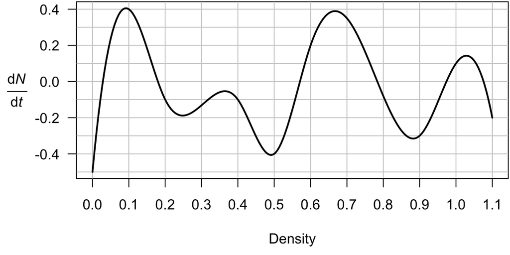

(So cute)

5. For the following ecological model of Allee effects, find the equilibria and, as a challenge, plot $\frac{\mathrm{d}N}{\mathrm{d}t}$ against $N$:
   $$\frac{\mathrm{d}N}{\mathrm{d}t} =
   rN\left(\frac{K-N}{K}\right)\left(\frac{N - A}{A}\right)$$
6. Of all of the new terminology you learned in this chapter, which would you use for the name of your band? What genre would it be?